# 2025_reu_hypothesis_7_densio

2025-07-21

## Hypothesis 7a: Seedlings with a higher canopy cover from the densiometer will have increased canker areas (shade hypothesis)

- Variables: Average densiometer rating → canker_area_base/trunk
- Mechanism: a priori prediction
- Linear regression

## Hypothesis 7b. Seedlings with a higher canopy cover from the south will have decreased canker areas

*Notice this is for seedlings only*

# Data Import

**Click for data import info**

## Importing 2024 & 2025 Data

See the full code for the break down for the importing and cleaning open the documents of the same name. Or here: - [2024 cleaning code](https://rpubs.com/hankhelmers/cleaning_2024_health_form_data) and - [2025 cleaning code](https://rpubs.com/hankhelmers/cleaning_2025_health_form_data)

### Create the R files if needed.

Purl (or stitch) together R code from the markdown cleaning files. These stitched files are stored in ‘purl’ folder with the date of the code purled.

```r
# library(knitr)
#
# purl("cleaning_2024_health_form_data.Rmd",
#      output =
#        paste("purl/cleaning_2024_health_form_data",
#        Sys.Date(),".R"))
#
# purl("cleaning_2025_health_form_data.Rmd",
#      output =
#        paste("purl/cleaning_2025_health_form_data",
#        Sys.Date(),".R"))
```

### Run the R files to get cleaned data

Next, we can run those extracted R files to actually import and clean the data.

```r
## 2024 data
source(paste("purl/cleaning_2024_health_form_data", Sys.Date(), ".R"))

## 2025 data
source(paste("purl/cleaning_2025_health_form_data", Sys.Date(), ".R"))
```

### Combining 2024 and 2025 data along canker area & DBH

```r
library(dplyr)

# Add a 'year' column to each dataset to allow grouping/plotting by year
health_assess_2024 <- health_assess_2024 %>%
  mutate(year = 2024)

health_assess_2025 <- health_assess_2025 %>%
  mutate(year = 2025)

# Keep only the necessary columns for this hypothesis
sliced_2024 <- health_assess_2024 %>%
  select(year, dbh_cm, percent_live_canopy, base_canker_area, trunk_canker_area)

sliced_2025 <- health_assess_2025 %>%
  select(year, dbh_cm, percent_live_canopy, base_canker_area, trunk_canker_area)

# Combine the two data frames
combined_2024_2025 <- bind_rows(sliced_2024, sliced_2025)
```

# Setup of Analysis

This chunk defines a re-usable function to run a regression across multiple input datas.

```r
do_hypoth7_analysis <- function(data, predictor, response, xlabel, ylabel, color = "black") {
  # EXPLICIT REMOVING NAs
  na.omit(data)

  # Define linear model
  model <- lm(reformulate(predictor, response), data = data)
  coefs <- coef(model)
  r_squared <- summary(model)$r.squared

  # Create equation and R^2 text
  equation <- paste0("y = ", round(coefs[2], 2), "x + ", round(coefs[1], 2))
  r2_text <- paste0("italic(R)^2 == ", round(r_squared, 4))

  # Get plotting ranges
  max_x <- max(data[[predictor]], na.rm = TRUE)

  max_y <- max(data[[response]], na.rm = TRUE)
  min_y <- min(data[[response]], na.rm = TRUE)
  range_y <- max_y - min_y

  # Annotate sample size near the bottom-right
  sample_size_y_position <- min_y + 0.08 * range_y

  # Annotate equation and r2 near the top-right
  eq_y_position <- max_y - 0.05 * range_y
  r2_y_position <- max_y - 0.12 * range_y

  # PLOT ------------------------------------------------------
  ggplot(data, aes_string(x = predictor, y = response)) +
    # Points
    geom_point(color = color) +

    # Line of best fit
    geom_smooth(method = "lm", color = color) +

    # Axes Label & Theme
    labs(x = xlabel, y = ylabel) +  # Set the y-axis label
    theme(
      axis.title.y = element_text(color = color) # Change y-axis label color
    ) +

    # Samples size text
    annotate(
      "text",
      x = max_x,
      y = sample_size_y_position,
      label = paste("n = ", count(data)),
      hjust = 1,
      size = 6,
      color = "black"
    ) +

    # Equation and R^2 text
    annotate(
      "text",
      x = max_x,
      y = eq_y_position,
      label = equation,
      hjust = 1,
      size = 4,
      color = color
    ) +
    annotate(
      "text",
      x = max_x,
      y = r2_y_position,
      label = r2_text,
      hjust = 1,
      size = 4,
      color = color,
      parse = TRUE # Ensures that italics styling works
    )
}
```

# Data Analysis: 7a

Here are the major delineations of questions across this hypotheses:

## Hypothesis 7a: Seedlings with a higher canopy cover from the densiometer will have increased canker areas (shade hypothesis)

Note: - Can’t investigate across years because only took densiometer measures in 2025 - Can’t investigate across age class because only took densiometer measures for seedlings

### Patterns across all seedlings

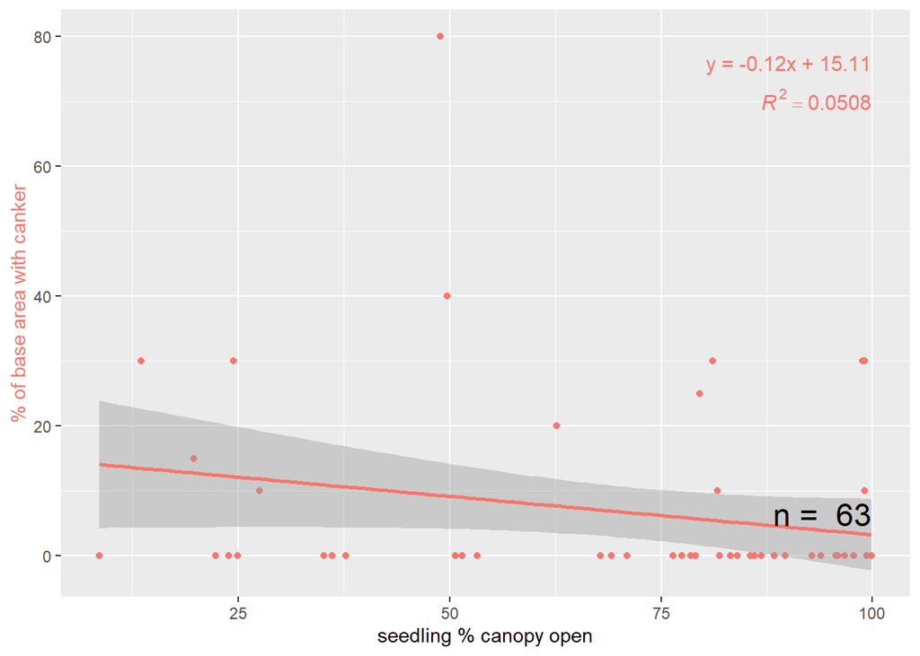

```r
library(scales)

hex <- hue_pal()(3)

seedlings_2025 <- health_assess_2025 %>% filter(is.na(dbh_cm))

patterns_across_seedling_base <- do_hypoth7_analysis(
  data = seedlings_2025,
  predictor = "densio_average",
  response = "base_canker_area",
  xlabel = "seedling % canopy open",
  ylabel = "% of base area with canker",
  color = hex[1]
)
patterns_across_seedling_base
```

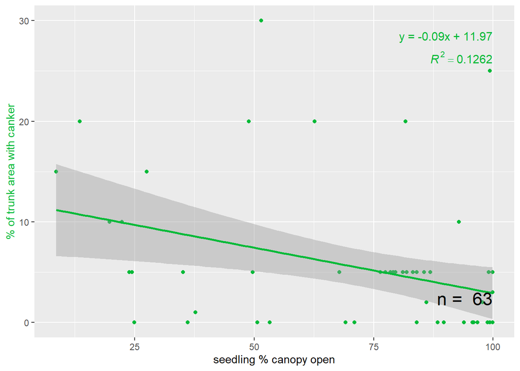

```r
patterns_across_seedling_trunk <- do_hypoth7_analysis(
  data = seedlings_2025,
  predictor = "densio_average",
  response = "trunk_canker_area",
  xlabel = "seedling % canopy open",
  ylabel = "% of trunk area with canker",
  color = hex[2]
)
patterns_across_seedling_trunk
```

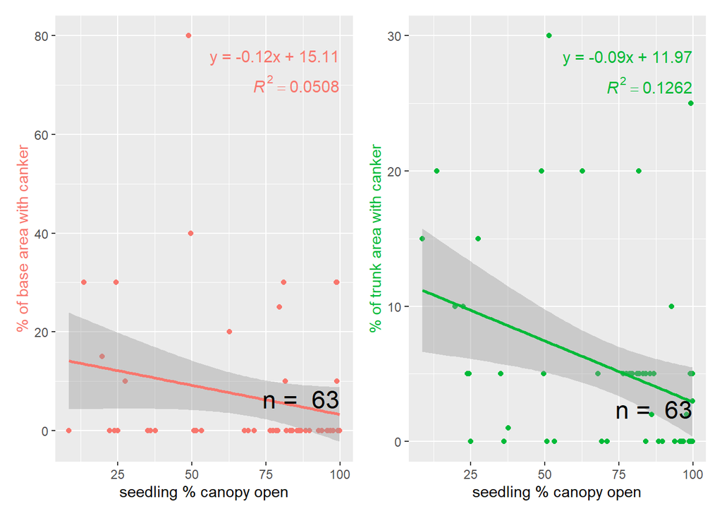

```r
library(patchwork)

(patterns_across_seedling_base + patterns_across_seedling_trunk) + plot_layout(guide = "collect")
```

# Data Analysis: 7b

## Hypothesis 7b. Seedlings with a higher canopy cover from the south will have decreased canker areas

### Patterns across each cardinal direction

#### North

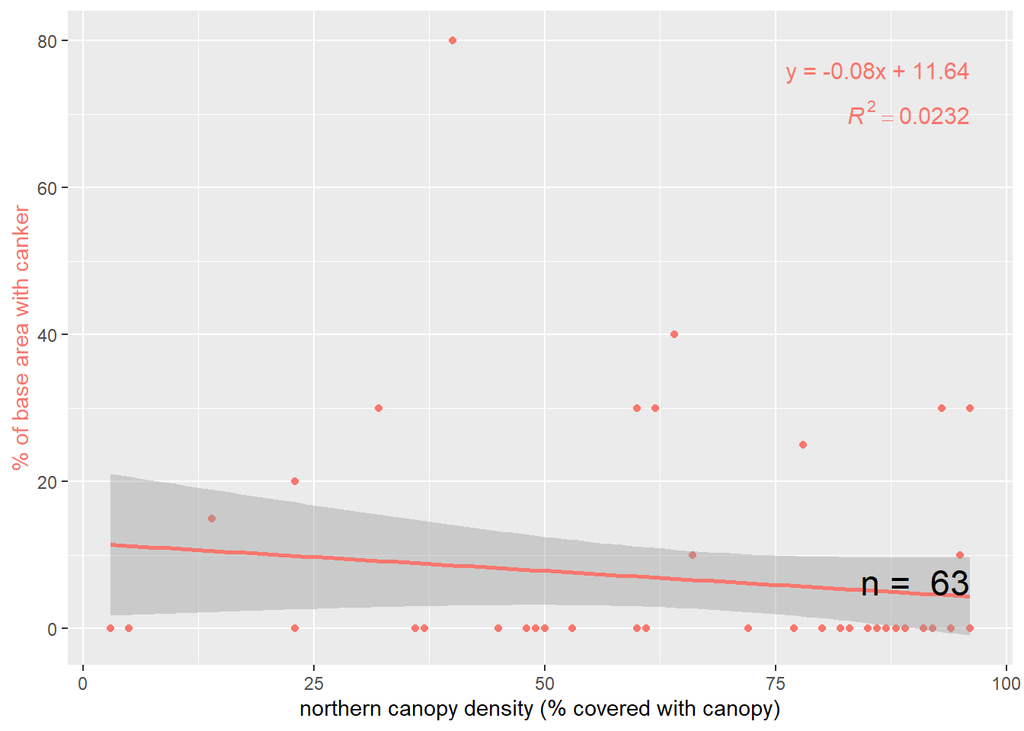

```r
library(scales)

hex <- hue_pal()(3)

seedlings_2025 <- health_assess_2025 %>% filter(is.na(dbh_cm))


patterns_across_north_base <- do_hypoth7_analysis(
  data = seedlings_2025,
  predictor = "densio_north",
  response = "base_canker_area",
  xlabel = "northern canopy density (% covered with canopy)",
  ylabel = "% of base area with canker",
  color = hex[1]
)
patterns_across_north_base
```

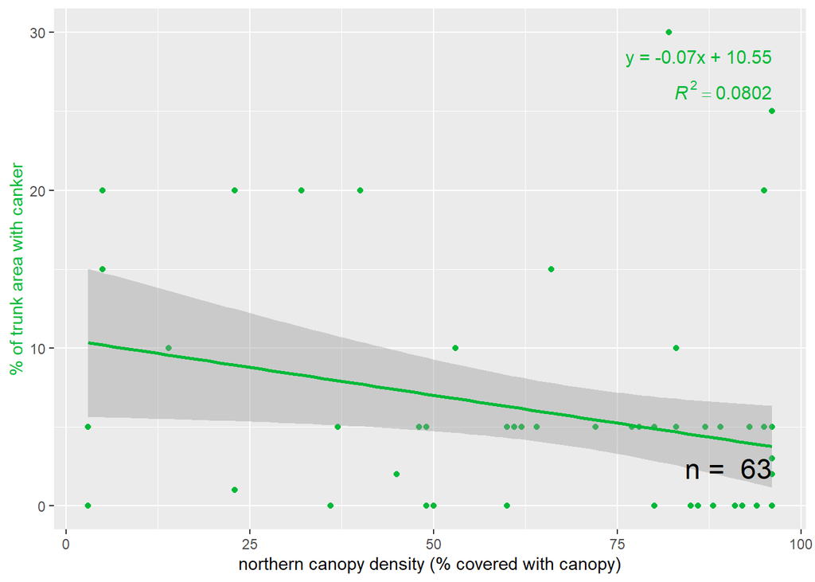

```r
patterns_across_north_trunk <- do_hypoth7_analysis(
  data = seedlings_2025,
  predictor = "densio_north",
  response = "trunk_canker_area",
  xlabel = "northern canopy density (% covered with canopy)",
  ylabel = "% of trunk area with canker",
  color = hex[2]
)
patterns_across_north_trunk
```

#### West

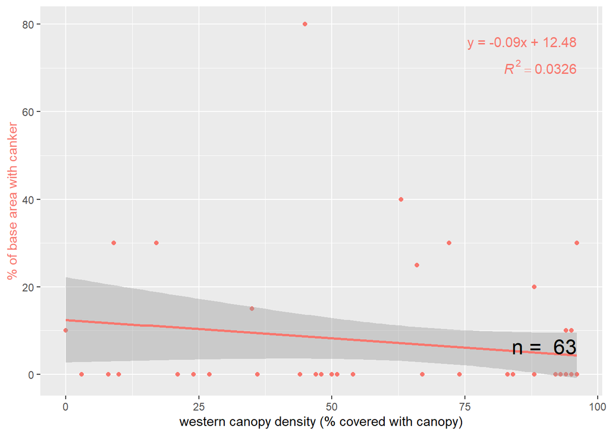

```r
library(scales)

hex <- hue_pal()(3)

seedlings_2025 <- health_assess_2025 %>% filter(is.na(dbh_cm))


patterns_across_west_base <- do_hypoth7_analysis(
  data = seedlings_2025,
  predictor = "densio_west",
  response = "base_canker_area",
  xlabel = "western canopy density (% covered with canopy)",
  ylabel = "% of base area with canker",
  color = hex[1]
)
patterns_across_west_base
```

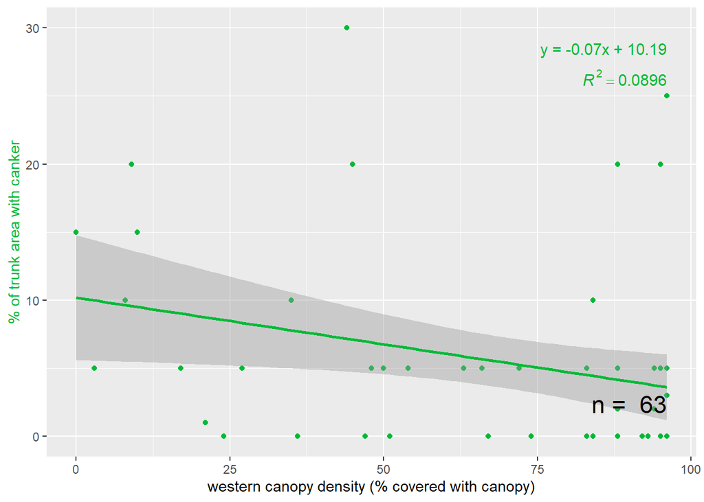

```r
patterns_across_west_trunk <- do_hypoth7_analysis(
  data = seedlings_2025,
  predictor = "densio_west",
  response = "trunk_canker_area",
  xlabel = "western canopy density (% covered with canopy)",
  ylabel = "% of trunk area with canker",
  color = hex[2]
)
patterns_across_west_trunk
```

#### South

[figure not shown]

```r
library(scales)

hex <- hue_pal()(3)

seedlings_2025 <- health_assess_2025 %>% filter(is.na(dbh_cm))

patterns_across_south_base <- do_hypoth7_analysis(
  data = seedlings_2025,
  predictor = "densio_south",
  response = "base_canker_area",
  xlabel = "southern canopy density (% covered with canopy)",
  ylabel = "% of base area with canker",
  color = hex[1]
)
patterns_across_north_base
```

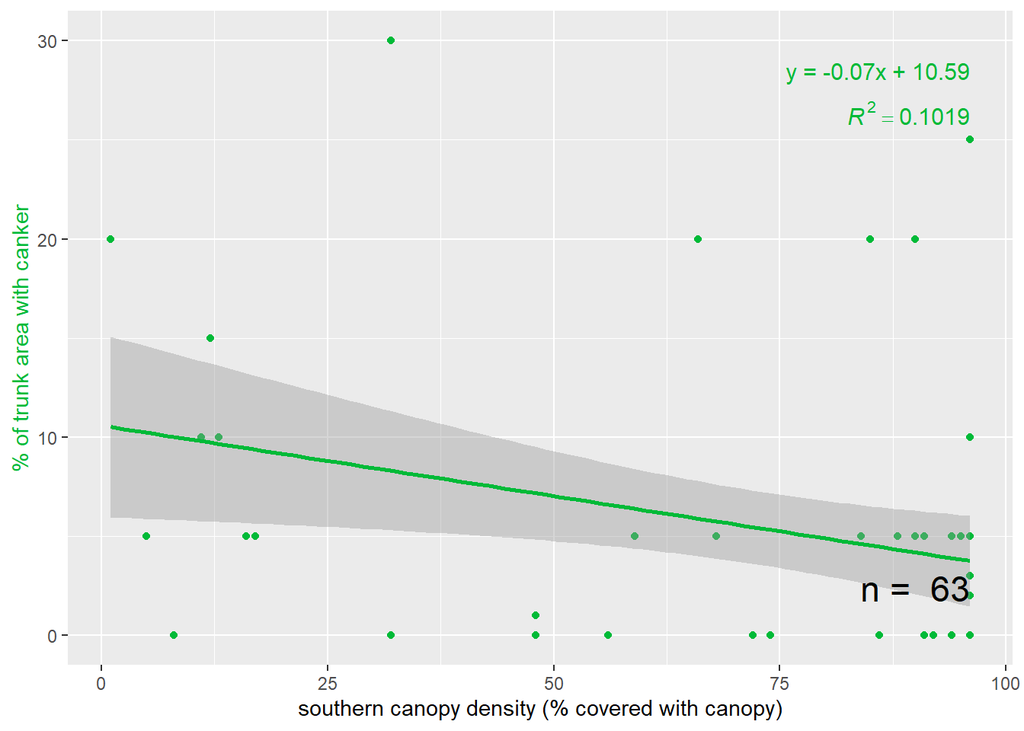

```r
patterns_across_south_trunk <- do_hypoth7_analysis(
  data = seedlings_2025,
  predictor = "densio_south",
  response = "trunk_canker_area",
  xlabel = "southern canopy density (% covered with canopy)",
  ylabel = "% of trunk area with canker",
  color = hex[2]
)
patterns_across_south_trunk
```

#### East

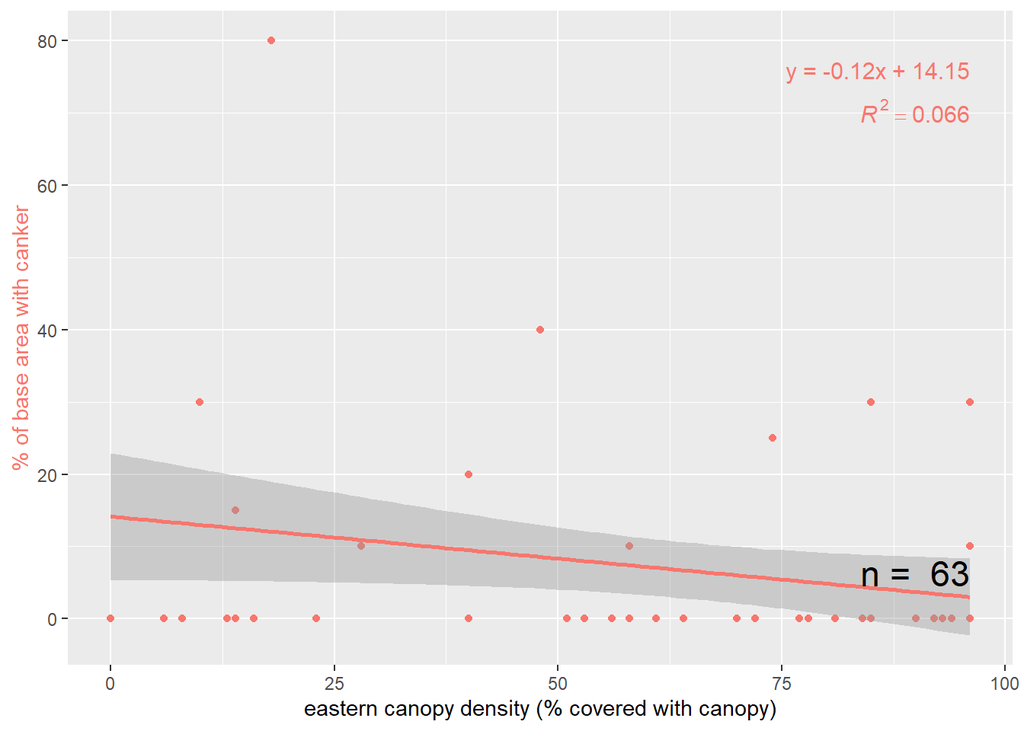

```r
library(scales)

hex <- hue_pal()(3)

seedlings_2025 <- health_assess_2025 %>% filter(is.na(dbh_cm))


patterns_across_east_base <- do_hypoth7_analysis(
  data = seedlings_2025,
  predictor = "densio_east",
  response = "base_canker_area",
  xlabel = "eastern canopy density (% covered with canopy)",
  ylabel = "% of base area with canker",
  color = hex[1]
)
patterns_across_east_base
```

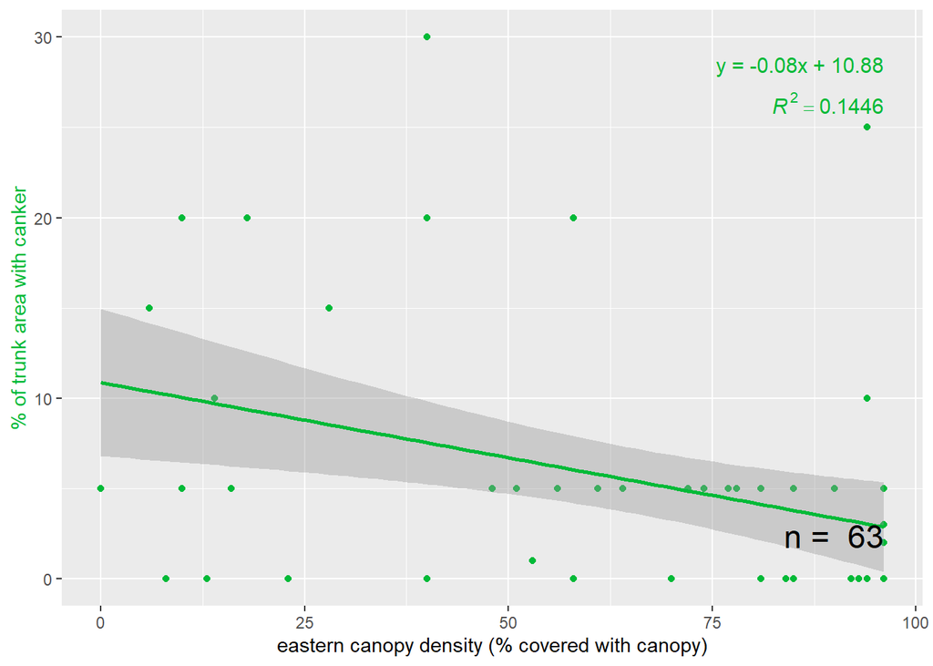

```r
patterns_across_east_trunk <- do_hypoth7_analysis(
  data = seedlings_2025,
  predictor = "densio_east",
  response = "trunk_canker_area",
  xlabel = "eastern canopy density (% covered with canopy)",
  ylabel = "% of trunk area with canker",
  color = hex[2]
)
patterns_across_east_trunk
```

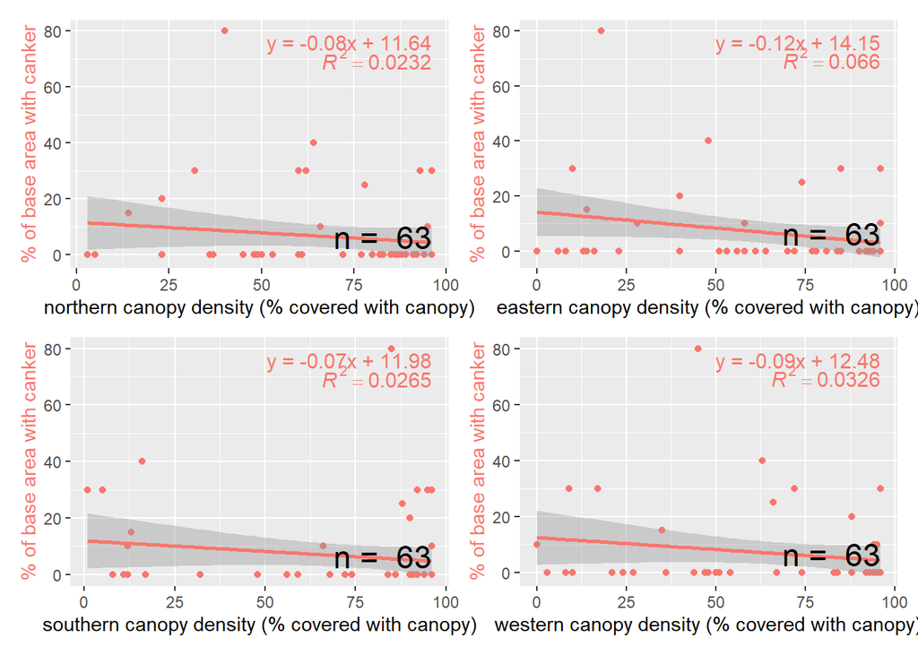

```r
(patterns_across_north_base + patterns_across_east_base) /
  (patterns_across_south_base + patterns_across_west_base)
```

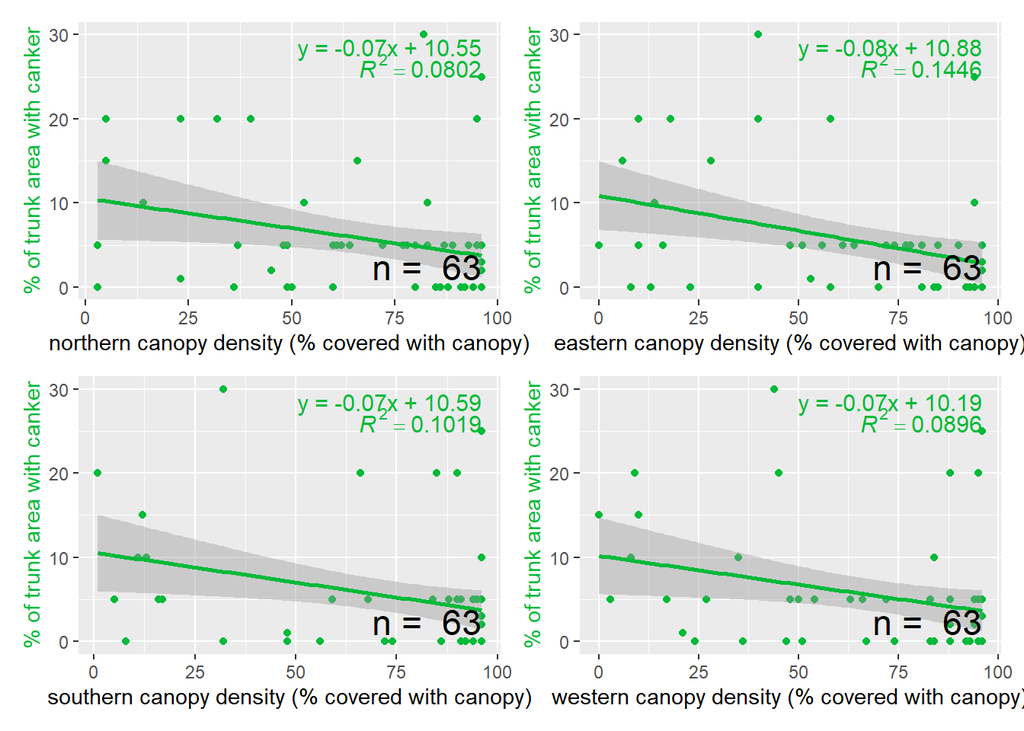

```r
(patterns_across_north_trunk + patterns_across_east_trunk) /
  (patterns_across_south_trunk + patterns_across_west_trunk)
```

### Distribution of densiometers across individuals

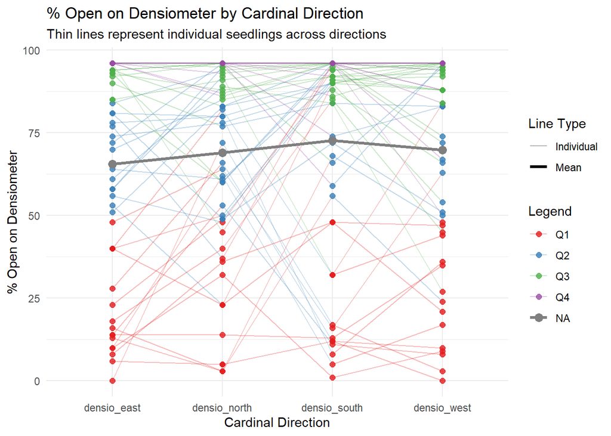

```r
library(tidyverse)
seedlings_2025 <- health_assess_2025 %>% filter(is.na(dbh_cm))

seedling_health_long <- seedlings_2025 %>%
  mutate(case_id = row_number()) %>%
  pivot_longer(
    cols = starts_with("densio_"),
    names_to = "direction",
    values_to = "percent_cover"
  ) %>%
  mutate(
    quartile = ntile(percent_cover, 4)  # 4 = quartiles
  )



seedling_health_long <- seedling_health_long %>%
  mutate(line_type = "Individual")  # add a dummy column to map linetype

seedling_health_long <- seedling_health_long %>%
  filter(direction != 'densio_average')

individual_spagetti <- seedling_health_long %>% ggplot(aes(x = direction, y = percent_cover, group = case_id)) +
  # Spaghetti lines with linetype
  geom_line(aes(linetype = line_type, color = factor(quartile)), alpha = 0.3) +

  # Points
  geom_point(aes(color = factor(quartile)), size = 2, alpha = 0.8) +

  # Mean line
  stat_summary(
    fun = mean,
    geom = "line",
    aes(group = 1, color = "Mean", linetype = "Mean"),
    size = 1.2
  ) +

  # Mean points
  stat_summary(
    fun = mean,
    geom = "point",
    aes(group = 1, color = "Mean"),
    size = 3
  ) +

  # Manual color and linetype scales
  scale_color_manual(
    name = "Legend",
    values = c(
      "1" = "#E41A1C",
      "2" = "#377EB8",
      "3" = "#4DAF4A",
      "4" = "#984EA3"
    ),
    labels = c("Q1", "Q2", "Q3", "Q4")
  ) +
  scale_linetype_manual(
    name = "Line Type",
    values = c("Individual" = "solid", "Mean" = "solid"),
    labels = c("Individual", "Mean")
  ) +

  theme_minimal() +
  labs(
    title = "% Open on Densiometer by Cardinal Direction",
    subtitle = "Thin lines represent individual seedlings across directions",
    x = "Cardinal Direction",
    y = "% Open on Densiometer"
  )
individual_spagetti
```